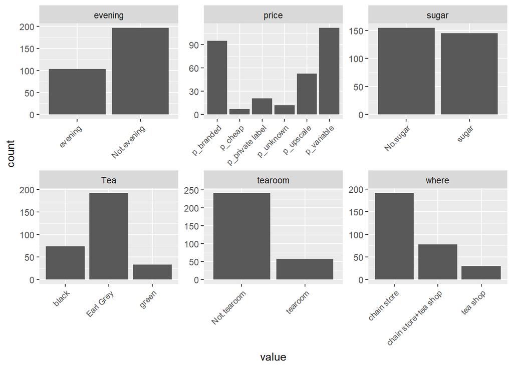

```r
# visualize the dataset
gather(tea_time) %>% ggplot(aes(value)) + facet_wrap("key", scales = "free")+ geom_bar() +theme(axis.text.x = element_text(angle = 45, hjust = 1, size = 8))
```

```r
mca <- MCA(tea_time, graph = FALSE)

# summary of the model

summary(mca)
```

```
##
## Call:
## MCA(X = tea_time, graph = FALSE)
##
##
## Eigenvalues
##                        Dim.1   Dim.2   Dim.3   Dim.4   Dim.5   Dim.6
## Variance               0.296   0.248   0.196   0.189   0.173   0.167
## % of var.             14.778  12.394   9.812   9.460   8.666   8.328
## Cumulative % of var.  14.778  27.173  36.985  46.445  55.110  63.438
##                        Dim.7   Dim.8   Dim.9  Dim.10  Dim.11  Dim.12
## Variance               0.160   0.146   0.131   0.116   0.107   0.072
## % of var.              7.985   7.279   6.541   5.822   5.327   3.607
## Cumulative % of var.  71.423  78.702  85.244  91.066  96.393 100.000
##
## Individuals (the 10 first)
##                    Dim.1    ctr   cos2    Dim.2    ctr   cos2    Dim.3
## 1               | -0.443  0.221  0.040 |  0.182  0.045  0.007 |  0.239
## 2               |  0.051  0.003  0.002 |  0.046  0.003  0.002 | -0.779
## 3               | -0.128  0.019  0.017 | -0.358  0.172  0.131 | -0.015
## 4               | -0.357  0.143  0.165 | -0.282  0.107  0.103 |  0.157
## 5               | -0.128  0.019  0.017 | -0.358  0.172  0.131 | -0.015
## 6               | -0.462  0.240  0.079 |  0.184  0.045  0.013 | -0.510
## 7               | -0.153  0.026  0.031 | -0.179  0.043  0.043 | -0.339
## 8               |  0.076  0.007  0.004 | -0.133  0.024  0.013 | -0.455
## 9               |  0.649  0.475  0.259 |  0.060  0.005  0.002 | -0.046
## 10              |  1.319  1.962  0.594 | -0.191  0.049  0.012 | -0.190
##                    ctr   cos2
## 1                0.097  0.012 |
## 2                1.031  0.521 |
## 3                0.000  0.000 |
## 4                0.042  0.032 |
## 5                0.000  0.000 |
## 6                0.442  0.097 |
## 7                0.196  0.154 |
## 8                0.351  0.148 |
## 9                0.004  0.001 |
## 10               0.061  0.012 |
##
## Categories (the 10 first)
```

[output cut: 16 more lines]

```
## Not.evening      4.394 | -0.296  4.892  0.168 -7.083 |
## p_branded        3.740 | -0.092  0.230  0.004 -1.088 |
## p_cheap         -0.149 | -0.583  0.674  0.008 -1.559 |
## p_private label  1.501 | -0.626  2.330  0.030 -2.970 |
## p_unknown       -0.181 |  1.214  5.006  0.061  4.285 |
## p_upscale        7.553 |  0.580  5.053  0.072  4.649 |
##
## Categorical variables (eta2)
##                   Dim.1 Dim.2 Dim.3
## Tea             | 0.080 0.353 0.244 |
## evening         | 0.001 0.065 0.168 |
## price           | 0.639 0.415 0.168 |
## tearoom         | 0.322 0.123 0.001 |
## where           | 0.621 0.508 0.163 |
## sugar           | 0.110 0.024 0.434 |
```

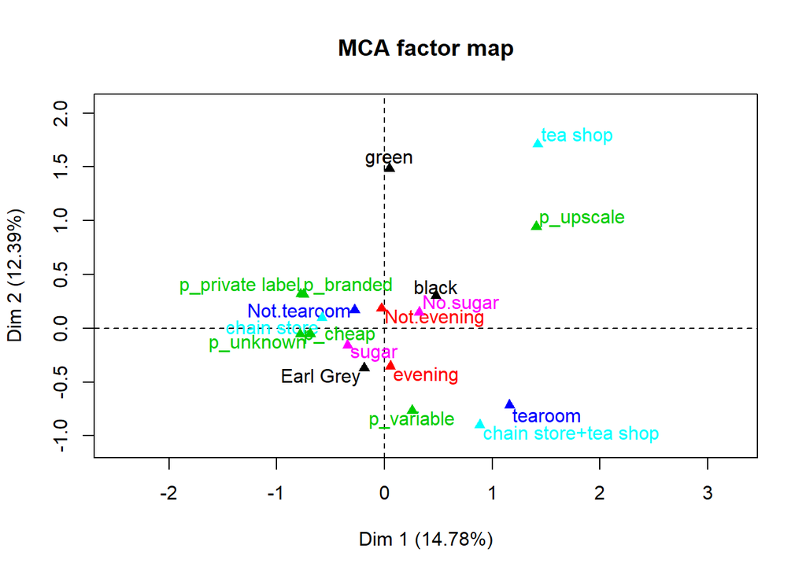

```r
# visualize MCA
plot(mca, invisible=c("ind"), habillage="quali")
```

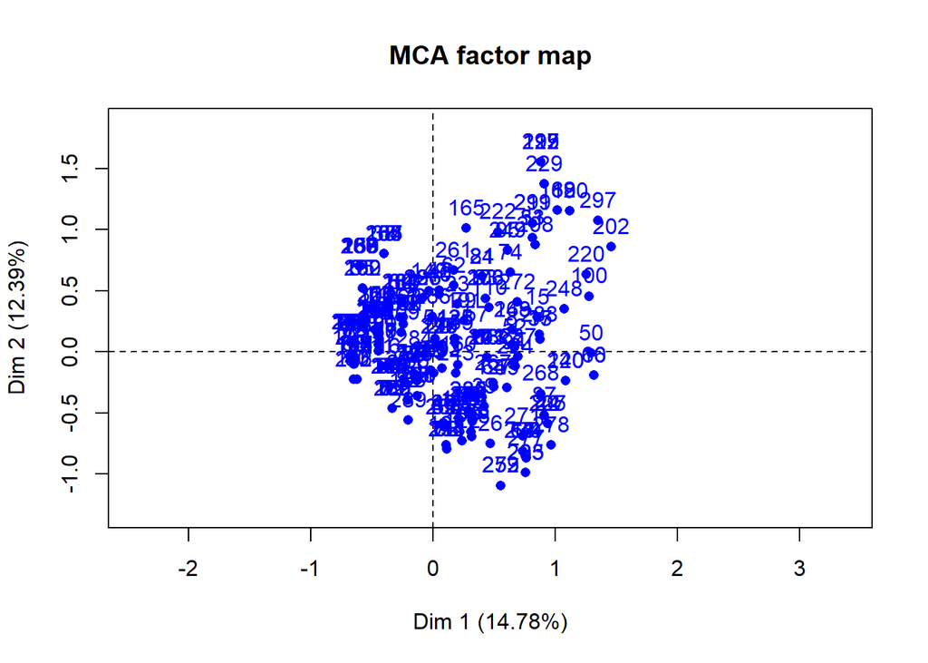

```r
plot(mca, invisible=c("var"), habillage="quali")
```

*the results of the Multiple Correspondence Analysis shows for all categoris the coordinates of the values, the contribution on the axis and the quality of representation measured by square of the cosine( which follows a gaussian distribution) on the 1st,2nd and 3rd dimension, the correlation ratio between variable(et2). Thus forexample black tea has coordinate 0.477 on the first axis (dim1), and its contribution is 3.159, and the v.test shows that black tea has large positive value(>1.96) in the first and second dimension while large negative value(<-1.96) in the third dimention*